# Life in BRC

## Experiences in Black Rock City, Community as Family, and Money Handling

## Experiences in Black Rock City

# Evaluation of Enjoyment of Experience* in Black Rock City

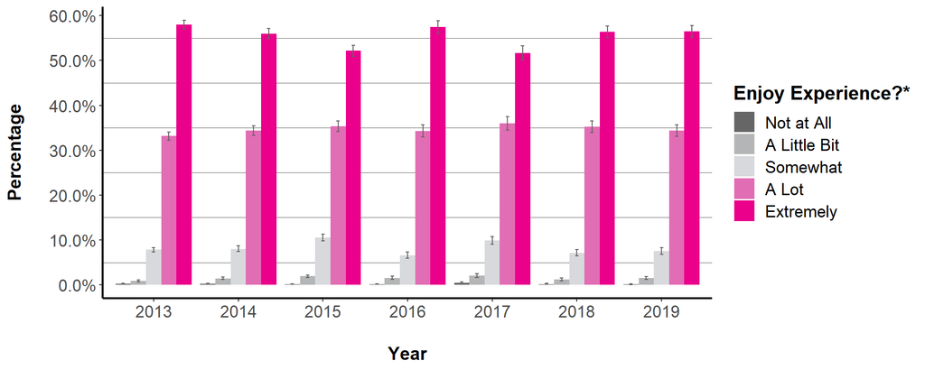

Error bars indicate the upper and lower bounds of the 95% confidence intervals.

* The exact wording of this question in the online survey was, "How much did you enjoy your experience this year in Black Rock City?"

|  | 2013 Percent | 2013 MoE +/- % |  | 2014 Percent | 2014 MoE +/- % |  | 2015 Percent | 2015 MoE +/- % |  | 2016 Percent | 2016 MoE +/- % |  | 2017 Percent | 2017 MoE +/- % |  | 2018 Percent | 2018 MoE +/- % |  | 2019 Percent | 2019 MoE +/- % |
| --- | --- | --- | --- | --- | --- | --- | --- | --- | --- | --- | --- | --- | --- | --- | --- | --- | --- | --- | --- | --- |
| Not at All | 0.2 | 0.0 |  | 0.2 | 0.0 |  | 0.1 | 0.0 |  | 0.1 | 0.0 |  | 0.4 | 0.2 |  | 0.1 | 0.0 |  | 0.1 | 0.0 |
| A Little Bit | 0.9 | 0.2 |  | 1.4 | 0.2 |  | 1.9 | 0.4 |  | 1.5 | 0.4 |  | 2.0 | 0.4 |  | 1.2 | 0.2 |  | 1.5 | 0.4 |
| Somewhat | 7.8 | 0.6 |  | 8.0 | 0.6 |  | 10.5 | 0.8 |  | 6.6 | 0.8 |  | 9.9 | 0.8 |  | 7.1 | 0.6 |  | 7.5 | 0.8 |
| A Lot | 33.2 | 1.0 |  | 34.4 | 1.0 |  | 35.3 | 1.2 |  | 34.3 | 1.4 |  | 36.0 | 1.6 |  | 35.2 | 1.2 |  | 34.4 | 1.2 |
| Extremely | 58.0 | 1.0 |  | 56.0 | 1.2 |  | 52.2 | 1.2 |  | 57.5 | 1.4 |  | 51.7 | 1.6 |  | 56.4 | 1.4 |  | 56.5 | 1.4 |

## Experiences in Black Rock City

# Evaluation of Feelings of Safety* in Black Rock City and Community of Residence

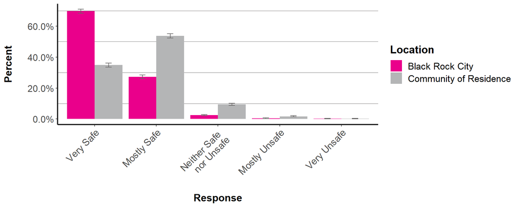

Error bars indicate the upper and lower bounds of the 95% confidence intervals.

* The exact wording of these questions in the online survey was, "Did you feel safe in Black Rock City this year?" and "Do you generally feel safe in the community (city, town or otherwise) in which you reside when not in Black Rock City?"

|  | Black Rock City Percent | Black Rock City MoE +/- % |  | Community of Residence Percent | Community of Residence MoE +/- % |  |
| --- | --- | --- | --- | --- | --- | --- |
| Very Safe | 69.7 | 1.2 |  | 34.9 | 1.4 |  |
| Mostly Safe | 27.2 | 1.2 |  | 53.8 | 1.4 |  |
| Neither Safe nor Unsafe | 2.5 | 0.4 |  | 9.4 | 0.8 |  |
| Mostly Unsafe | 0.5 | 0.2 |  | 1.7 | 0.4 |  |
| Very Unsafe | 0.2 | 0.2 |  | 0.2 | 0.2 |  |

## Experiences in Black Rock City

# Evaluation of Feelings of Connectedness* in Black Rock City and Community of Residence

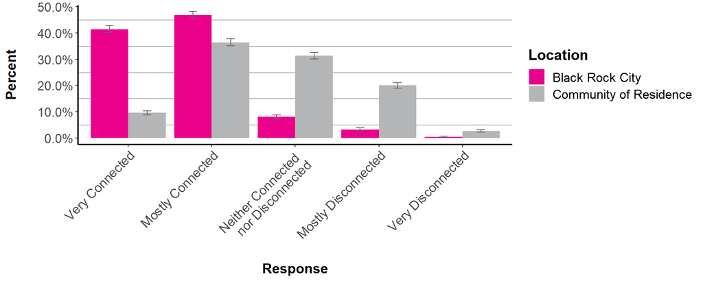

Error bars indicate the upper and lower bounds of the 95% confidence intervals.

* The exact wording of these questions in the online survey was, "Did you feel connected to others around you in Black Rock City this year?" and "Do you generally feel connected to others in the community (city, town or otherwise) in which you reside when not in Black Rock City?"

|  | Black Rock City Percent | Black Rock City MoE +/- % |  | Community of Residence Percent | Community of Residence MoE +/- % |  |
| --- | --- | --- | --- | --- | --- | --- |
| Very Connected | 41.4 | 1.4 |  | 9.6 | 0.8 |  |
| Mostly Connected | 46.8 | 1.4 |  | 36.4 | 1.4 |  |
| Neither Connected nor Disconnected | 8.1 | 0.8 |  | 31.3 | 1.2 |  |
| Mostly Disconnected | 3.3 | 0.4 |  | 20.0 | 1.0 |  |
| Very Disconnected | 0.5 | 0.2 |  | 2.7 | 0.4 |  |

## Experiences in Black Rock City

# Evaluatiuon of feelings of freedom in Black Rock City*

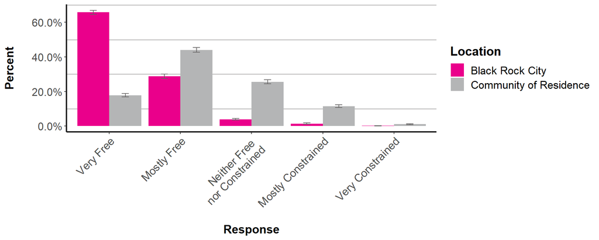

Error bars indicate the upper and lower bounds of the 95% confidence intervals.

*The exact wording of these questions was "Did you feel free (to explore, try new things, express yourself, be spontaneous, take risks)? and "Do you generally feel free (to explore, try new things, express yourself, be spontaneous, take risks) in the community (city, town or otherwise) in which you reside when not in Black Rock City?"

|  | Black Rock City Percent | Black Rock City MoE +/- % |  | Community of Residence Percent | Community of Residence MoE +/- % |  |
| --- | --- | --- | --- | --- | --- | --- |
| Very Free | 65.8 | 1.4 |  | 17.8 | 1.0 |  |
| Mostly Free | 28.8 | 1.2 |  | 44.0 | 1.4 |  |
| Neither Free nor Constrained | 3.9 | 0.6 |  | 25.6 | 1.2 |  |
| Mostly Constrained | 1.4 | 0.4 |  | 11.5 | 0.8 |  |
| Very Constrained | 0.2 | 0.2 |  | 1.1 | 0.2 |  |

## Experiences in Black Rock City

# Participation in Musical Activities in the Past Year*

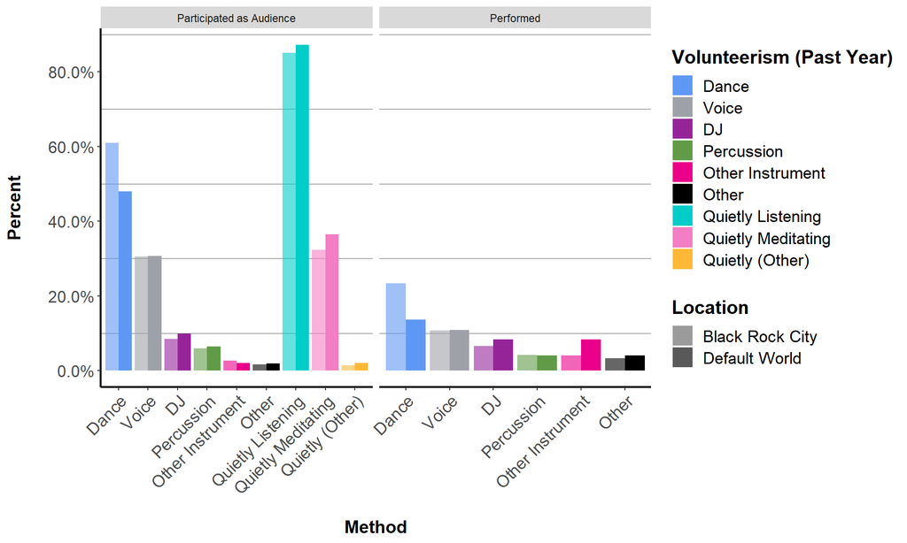

Participants selected all option(s) that applied.  
*This question was first asked in 2019.

|  | Black Rock City Percent | Black Rock City MoE +/- % |  | Default World Percent | Default World MoE +/- % |
| --- | --- | --- | --- | --- | --- |
| Participated as Audience |  |  |  |  |  |
| Dance | 61.0 | 1.4 |  | 48.0 | 1.4 |
| Voice | 30.6 | 1.2 |  | 30.7 | 1.2 |
| DJ | 8.5 | 0.8 |  | 9.8 | 0.8 |
| Percussion | 6.0 | 0.6 |  | 6.4 | 0.6 |
| Other Instrument | 2.6 | 0.4 |  | 2.0 | 0.4 |
| Other | 1.7 | 0.4 |  | 1.9 | 0.4 |
| Quietly Listening | 85.1 | 1.0 |  | 87.2 | 1.0 |
| Quietly Meditating | 32.3 | 1.4 |  | 36.5 | 1.4 |
| Quietly (Other) | 1.4 | 0.4 |  | 2.0 | 0.4 |
| Performed |  |  |  |  |  |
| Dance | 23.3 | 1.2 |  | 13.7 | 1.0 |
| Voice | 10.8 | 0.8 |  | 10.9 | 0.8 |
| DJ | 6.6 | 0.8 |  | 8.3 | 0.8 |
| Percussion | 4.2 | 0.6 |  | 4.0 | 0.6 |
| Other Instrument | 4.0 | 0.6 |  | 8.4 | 0.8 |
| Other | 3.3 | 0.4 |  | 4.1 | 0.6 |

## Money Handling While in Black Rock City

# Money Handling While in Black Rock City

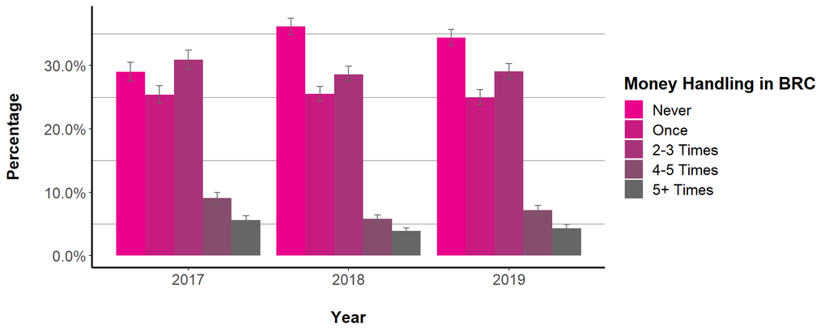

Error bars indicate the upper and lower bounds of the 95% confidence intervals.

|  | 2017 Percent | 2017 MoE +/- % |  | 2018 Percent | 2018 MoE +/- % |  | 2019 Percent | 2019 MoE +/- % |
| --- | --- | --- | --- | --- | --- | --- | --- | --- |
| Never | 29.0 | 1.6 |  | 36.2 | 1.4 |  | 34.4 | 1.4 |
| Once | 25.4 | 1.4 |  | 25.5 | 1.2 |  | 25.0 | 1.2 |
| 2-3 Times | 30.9 | 1.4 |  | 28.6 | 1.2 |  | 29.1 | 1.2 |
| 4-5 Times | 9.1 | 1.0 |  | 5.8 | 0.6 |  | 7.2 | 0.6 |
| 5+ Times | 5.6 | 0.6 |  | 3.9 | 0.4 |  | 4.3 | 0.6 |

**Next:** Life in BRC: Camp Location, Camp Size, Family, Minors, and RV/Camper Use